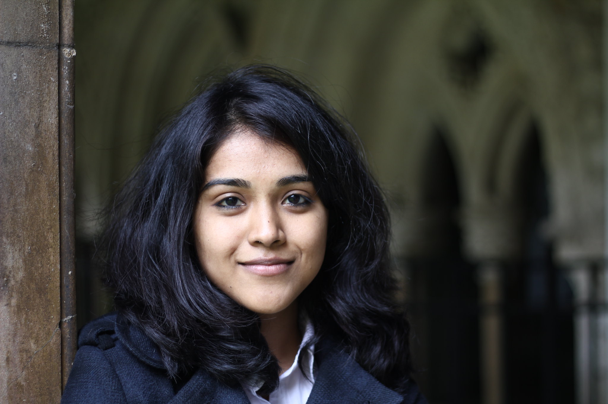

# Divya Venkatesh

## Bio

I am a biologist with an interest in infectious diseases from evolutionary and immunological perspectives.

In my postdoc, I focussed on the evolution and transmission dynamics of influenza A viruses across species barriers in human, livestock and wild hosts. I collaborated with the CEIRS (Centers for excellence in influenza research and surveillance) network to asses pandemic risk from swine influenza A viruses. I worked with the UK government’s APHA (Animal and plant health agency) to investigate outbreaks of highly pathogenic avian influenza (HPAI) in poultry. I also led the analysis for the Avian Influenza Reports for the biannual WHO Vaccine Composition Meetings which inform vaccine development for potential zoonotic influenza outbreaks.

Since July 2020 I have been on maternity leave and I am currently plotting my return to work…

## Education

**University of Cambridge, Queens’ College** Department of Pathology | Cambridge, UK  
Ph.D. in Parasitology (Gates Scholar) | October 2011 - April 2016

**Newcastle University** | Newcastle upon Tyne, UK  
MRes in Medical and Molecular Biosciences | September 2007 - August 2008

**Bangalore University** | SBM Jain College, Bangalore, India  
BSc Biotechnology | June 2004 - June 2007

## Experience

**The Royal Veterinary College** Department of Pathobiology and Population Sciences (2018-2020) & **University of Cambridge**, Department of Zoology (2016-2018)  
Postdoctoral researcher | October 2016 - July 2020

**Newcastle University** Institute of Genetic Medicine  
Research Assistant | September 2008 - August 2011